# Lab1: Hadoop Distributed File System (HDFS)

### Student Name : [Monier Ashraf Monier Lawande]

### Student ID: [221002188]

## Lab Goals:

1. Quick Overview of Hadoop Storage and processing components.
2. Learn how Hadoop Distributed File System (HDFS) stores data across a cluster.
3. Get familiar with using HDFS using hdfs commands or Hue file browser.
4. Practice and submit MapReduce jobs.

## Hadoop

Set of open source procedures and programs that can be used as a framework for big data operations.

### Hadoop main components

Hadoop has three main components as in the figure below. In this lab we are going to explore:

1. Hadoop Distributed File System (HDFS): The storage unit of Hadoop.
2. Hadoop MapReduce: The processing unit of Hadoop.
3. Recource Management: Tracking the resources in a cluster, and scheduling applications.

[figure not shown]

## HDFS basics:

HDFS is the hadoop distributed file system which is written in java.  
In the cluster, there will be a:

- **NameNode:** which stores meta-data of data blocks.
- **DataNodes:** which contain the actual data blocks.

For the sake of fault tolerance, HDFS stores redundant copies of each data block (by default = 3).

[figure not shown]

## Storing and retreiving files in HDFS:

Files are split into 128 MB blocks by default and each block is replicated in multipe data nodes.

[figure not shown]

# Command Line access to HDFS:

## Fs Shell commands [hdfs dfs]:

In the VM terminal, you can use commands like the following:

| Function | Command |
| --- | --- |
| Copy *file1.txt* from local directory to hfds | \$ hdfs dfs -put *file1.txt* /*dir/file1.txt* |
| Copy file to local directory *dir* and change name to *file2.txt* | \$ hdfs dfs -get /*dir/file1.txt* *file2.txt* |
| Create directory *dire1* | \$ hdfs dfs -mkdir *dire1* |
| Delete directory *dire1* | \$ hdfs dfs -rm -r *dire1* |
| List UP file in a directory *dir* | \$ hdfs dfs -ls /dir |
| List up the files in hdfs root directory | \$ hdfs dfs -ls / |
| display content in file *file1.txt* | \$ hdfs dfs -cat /*dir*/*file1.txt* |

## Task 1: Use Hue to manage your files:

The Hue HDFS file browser is an open source file browser built by Cloudera. It allows managing your HDFS directories and files from an easy graphical web user interface.  
Hue can be accessed from [port 8989 on local host](http://127.0.0.1:8989/hue/accounts/login?next=/)

```python
from IPython.display import Image
```

[figure not shown]

```python
Image(filename="/home/bitnami/Big_Data_Labs/lab1/Images/hue2.png")
```

## Task 2

### Running Hadoop MapReduce (word count example):

To run this example, you need to extract the zip file attached with the assignment file on Moodle.

1.In your local directory `/home/bitnami`, create a folder called `Labs` and then subfolder `Lab1`. Move the downloaded zip file to `Lab1` and then extract it.

In this task, we are going to run a simple example that count words frequency using Hadoop MapReduce.  
We will start by using hdfs commands to create a directory for our input.

1. create a directory with name "hdfslab2":  
   `hdfs dfs -mkdir hdfsLab1`
2. Create a subdirectory "input":  
   `hdfs dfs -mkdir hdfsLab1/input`
3. Change the local directroy to "Labs/Lab1":  
   `cd /home/bitnami/Labs/Lab1/`
4. Move the file "AliceInWonderLandPart1.txt", in the extracted folder, to the hdfs cluster:  
   `hdfs dfs -put /home/bitnami/Labs/Lab1/AliceInWonderLandPart1.txt /user/hadoop/hdfsLab1/input`
5. Now it is time to run our first MapReduce example "wordcount" using the following command:  
   `hadoop jar /home/bitnami/Labs/Lab1/WordCount.jar ee.ut.cs.dsg.bigdatamanagement.WordCount /home/bitnami/hdfsLab1/input /user/hadoop/hdfsLab1/output`

## 2.1 Unzip The Attached File

- Move HDFSLAB.zip from /home/bitnami to Lab1

```python
mv /home/bitnami/Big_Data_Labs/HDFSLAB.zip /home/bitnami/Big_Data_Labs/lab1/
```

- unzip HDFSLAB.zip

```python
!unzip /home/bitnami/Big_Data_Labs/lab1/HDFSLAB.zip -d /home/bitnami/Big_Data_Labs/lab1/
```

[output not shown]

[output cut: 20 more lines]

## 2.2 Word Count

- Run the simple example that count words frequency using Hadoop MapReduce.

[figure not shown]

1. create a directory with name "HadoopLab1":  
   `!hdfs dfs -mkdir hadoopLab1`

```python
!hdfs dfs -mkdir hadooplab1
```

- Put screenshot of hue showing the Directory

[figure not shown]

```python
Image(filename='/home/bitnami/Big_Data_Labs/lab1/Images/hue3.png')
```

1. Create a subdirectory "input":  
   **`!hdfs dfs -mkdir hadoopLab1/input`**

```python
!hdfs dfs -mkdir hadooplab1/input2
```

```python
!hdfs dfs -mkdir hadooplab1/output3
```

- list the files in hadoopLab1 directory:  
  `!hdfs dfs -ls /user/hadoop/hadoopLab1/`

```python
!hdfs dfs -ls /user/hadoop/hadooplab1/
```

[output not shown]

1. Move the file "AliceInWonderLandPart1.txt", in the extracted folder, to the hdfs cluster input directory:  
   `!hdfs dfs -put /home/bitnami/Big-Data-Labs/Lab1/AliceInWonderLandPart1.txt /user/hadoop/hadoopLab1/input`

```python
!hdfs dfs -put /home/bitnami/Big_Data_Labs/lab1/AliceInWonderLandPart1.txt /user/hadoop/hadooplab1/input2
```

[figure not shown]

```python
Image(filename="/home/bitnami/Big_Data_Labs/lab1/Images/hue4.png")
```

- list the files in hadoopLab1/input directory:  
  `!hdfs dfs -ls /user/hadoop/hadoopLab1/input/`

```python
!hdfs dfs -ls /user/hadoop/hadooplab1/input2/
```

```
Found 1 items
-rw-r--r--   1 hadoop hadoop       1218 2022-11-05 13:38 /user/hadoop/hadooplab1/input2/AliceInWonderLandPart1.txt
```

1. Now it is time to run our first MapReduce example "wordcount" using the following command:  
   `!hadoop jar /home/bitnami/Big-Data-Labs/Lab1/WordCount.jar ee.ut.cs.dsg.bigdatamanagement.WordCount /user/hadoop/hadoopLab1/input /user/hadoop/hadoopLab1/output`

```python
!hadoop jar /home/bitnami/Big_Data_Labs/lab1/WordCount.jar ee.ut.cs.dsg.bigdatamanagement.WordCount /user/hadoop/hadooplab1/input2 /user/hadoop/hadooplab1/output4
```

```
2022-11-05 13:40:23,069 INFO client.RMProxy: Connecting to ResourceManager at /0.0.0.0:8032
2022-11-05 13:40:24,437 INFO mapreduce.JobResourceUploader: Disabling Erasure Coding for path: /tmp/hadoop-yarn/staging/hadoop/.staging/job_1667650619163_0003
2022-11-05 13:40:25,160 INFO input.FileInputFormat: Total input files to process : 1
2022-11-05 13:40:25,352 INFO mapreduce.JobSubmitter: number of splits:1
2022-11-05 13:40:25,483 INFO Configuration.deprecation: yarn.resourcemanager.system-metrics-publisher.enabled is deprecated. Instead, use yarn.system-metrics-publisher.enabled
2022-11-05 13:40:25,842 INFO mapreduce.JobSubmitter: Submitting tokens for job: job_1667650619163_0003
2022-11-05 13:40:25,846 INFO mapreduce.JobSubmitter: Executing with tokens: []
2022-11-05 13:40:26,450 INFO conf.Configuration: resource-types.xml not found
2022-11-05 13:40:26,450 INFO resource.ResourceUtils: Unable to find 'resource-types.xml'.
2022-11-05 13:40:26,654 INFO impl.YarnClientImpl: Submitted application application_1667650619163_0003
2022-11-05 13:40:26,820 INFO mapreduce.Job: The url to track the job: http://localhost:8088/proxy/application_1667650619163_0003/
2022-11-05 13:40:26,822 INFO mapreduce.Job: Running job: job_1667650619163_0003
2022-11-05 13:40:43,441 INFO mapreduce.Job: Job job_1667650619163_0003 running in uber mode : false
2022-11-05 13:40:43,445 INFO mapreduce.Job:  map 0% reduce 0%
2022-11-05 13:40:53,665 INFO mapreduce.Job:  map 100% reduce 0%
2022-11-05 13:41:04,820 INFO mapreduce.Job:  map 100% reduce 100%
2022-11-05 13:41:05,848 INFO mapreduce.Job: Job job_1667650619163_0003 completed successfully
2022-11-05 13:41:06,125 INFO mapreduce.Job: Counters: 54
	File System Counters
		FILE: Number of bytes read=4352
		FILE: Number of bytes written=452047
		FILE: Number of read operations=0
		FILE: Number of large read operations=0
		FILE: Number of write operations=0
		HDFS: Number of bytes read=1361
		HDFS: Number of bytes written=1035
		HDFS: Number of read operations=8
		HDFS: Number of large read operations=0
		HDFS: Number of write operations=2
		HDFS: Number of bytes read erasure-coded=0
	Job Counters
		Launched map tasks=1
		Launched reduce tasks=1
		Data-local map tasks=1
		Total time spent by all maps in occupied slots (ms)=15656
		Total time spent by all reduces in occupied slots (ms)=16906
		Total time spent by all map tasks (ms)=7828
		Total time spent by all reduce tasks (ms)=8453
		Total vcore-milliseconds taken by all map tasks=7828
		Total vcore-milliseconds taken by all reduce tasks=8453
```

[output cut: 23 more lines]

```
		Peak Map Physical memory (bytes)=218124288
		Peak Map Virtual memory (bytes)=3509850112
		Peak Reduce Physical memory (bytes)=168140800
		Peak Reduce Virtual memory (bytes)=3518849024
	Shuffle Errors
		BAD_ID=0
		CONNECTION=0
		IO_ERROR=0
		WRONG_LENGTH=0
		WRONG_MAP=0
		WRONG_REDUCE=0
	File Input Format Counters
		Bytes Read=1218
	File Output Format Counters
		Bytes Written=1035
```

- Put a screenshot of Hadoop Dashboard while runnig the wordcount task

[figure not shown]

```python
Image(filename="/home/bitnami/Big_Data_Labs/lab1/Images/hadoop1.png")
```

- Display the output:  
  `!hdfs dfs -cat hadoopLab1/output/part-r-00000`

```python
!hdfs dfs -cat hadooplab1/output4/part-r-00000
```

```
	212
!	3
!"	1
(	1
),	1
,	13
, "	3
,"	1
-	4
.	3
?"	1
A	8
ACROSS	2
ACTUALLY	1
AFTER	2
ALICE	5
AND	8
ANOTHER	1
AS	2
AT	1
BANK	1
BE	2
BEFORE	1
BEGINNING	1
BOOK	2
BURNING	1
BUT	2
BY	2
CHAIN	1
CLOSE	1
CONSIDERING	1
CONVERSATIONS	2
COULD	1
CURIOSITY	1
DAISIES	1
DAISY	1
DAY	1
DEAR	2
DID	1
DO	1
```

[output cut: 84 more lines]

```
VERY	4
WAISTCOAT	2
WAS	5
WATCH	2
WAY	1
WELL	1
WENT	1
WHAT	1
WHEN	2
WHETHER	1
WHITE	1
WITH	3
WITHOUT	1
WORTH	1
WOULD	1
```

## 2.3 Word Count with Excluding Stop Words

In this task, we are going to exclude the words that we want to filter out (stop words). We will pass the set of stop words which we want to exclude.

1. Move Stopwords.txt file to /user/hadoop/hadoopLab1/
2. Run the word count skip stop words  
   `!hadoop jar /home/bitnami/Big-Data-Labs/Lab1/WordCount.jar ee.ut.cs.dsg.bigdatamanagement.WordCountSkipStopWord hadoopLab1/input hadoopLab1/output2 -skip hadoopLab1/StopWords.txt`
3. Put screenshot of Hadoop Dashboard while runnig the job
4. Dispaly the output using -cat command

```python
#WordCountSkipStopWord.java
```

```python
# Move stopwords
!hdfs dfs -put /home/bitnami/Big_Data_Labs/lab1/StopWords.txt /user/hadoop/hadooplab1/input2
```

```python
# Run word count skip stop words
!hadoop jar /home/bitnami/Big_Data_Labs/lab1/WordCount.jar ee.ut.cs.dsg.bigdatamanagement.WordCountSkipStopWord hadooplab1/input2 hadooplab1/output5 -skip hadooplab1/input2/StopWords.txt
```

```
2022-11-05 13:56:07,905 INFO client.RMProxy: Connecting to ResourceManager at /0.0.0.0:8032
2022-11-05 13:56:09,263 INFO mapreduce.JobResourceUploader: Disabling Erasure Coding for path: /tmp/hadoop-yarn/staging/hadoop/.staging/job_1667650619163_0004
2022-11-05 13:56:09,982 INFO input.FileInputFormat: Total input files to process : 2
2022-11-05 13:56:10,149 INFO mapreduce.JobSubmitter: number of splits:2
2022-11-05 13:56:10,258 INFO Configuration.deprecation: yarn.resourcemanager.system-metrics-publisher.enabled is deprecated. Instead, use yarn.system-metrics-publisher.enabled
2022-11-05 13:56:10,630 INFO mapreduce.JobSubmitter: Submitting tokens for job: job_1667650619163_0004
2022-11-05 13:56:10,633 INFO mapreduce.JobSubmitter: Executing with tokens: []
2022-11-05 13:56:11,189 INFO conf.Configuration: resource-types.xml not found
2022-11-05 13:56:11,190 INFO resource.ResourceUtils: Unable to find 'resource-types.xml'.
2022-11-05 13:56:11,459 INFO impl.YarnClientImpl: Submitted application application_1667650619163_0004
2022-11-05 13:56:11,637 INFO mapreduce.Job: The url to track the job: http://localhost:8088/proxy/application_1667650619163_0004/
2022-11-05 13:56:11,640 INFO mapreduce.Job: Running job: job_1667650619163_0004
2022-11-05 13:56:27,108 INFO mapreduce.Job: Job job_1667650619163_0004 running in uber mode : false
2022-11-05 13:56:27,110 INFO mapreduce.Job:  map 0% reduce 0%
2022-11-05 13:56:37,362 INFO mapreduce.Job:  map 50% reduce 0%
2022-11-05 13:56:46,596 INFO mapreduce.Job:  map 100% reduce 0%
2022-11-05 13:56:57,776 INFO mapreduce.Job:  map 100% reduce 100%
2022-11-05 13:56:57,794 INFO mapreduce.Job: Job job_1667650619163_0004 completed successfully
2022-11-05 13:56:58,034 INFO mapreduce.Job: Counters: 54
	File System Counters
		FILE: Number of bytes read=1522
		FILE: Number of bytes written=672196
		FILE: Number of read operations=0
		FILE: Number of large read operations=0
		FILE: Number of write operations=0
		HDFS: Number of bytes read=1518
		HDFS: Number of bytes written=993
		HDFS: Number of read operations=11
		HDFS: Number of large read operations=0
		HDFS: Number of write operations=2
		HDFS: Number of bytes read erasure-coded=0
	Job Counters
		Launched map tasks=2
		Launched reduce tasks=1
		Data-local map tasks=2
		Total time spent by all maps in occupied slots (ms)=32290
		Total time spent by all reduces in occupied slots (ms)=18032
		Total time spent by all map tasks (ms)=16145
		Total time spent by all reduce tasks (ms)=9016
		Total vcore-milliseconds taken by all map tasks=16145
```

[output cut: 24 more lines]

```
		Peak Map Physical memory (bytes)=423075840
		Peak Map Virtual memory (bytes)=3511259136
		Peak Reduce Physical memory (bytes)=169762816
		Peak Reduce Virtual memory (bytes)=3519275008
	Shuffle Errors
		BAD_ID=0
		CONNECTION=0
		IO_ERROR=0
		WRONG_LENGTH=0
		WRONG_MAP=0
		WRONG_REDUCE=0
	File Input Format Counters
		Bytes Read=1245
	File Output Format Counters
		Bytes Written=993
```

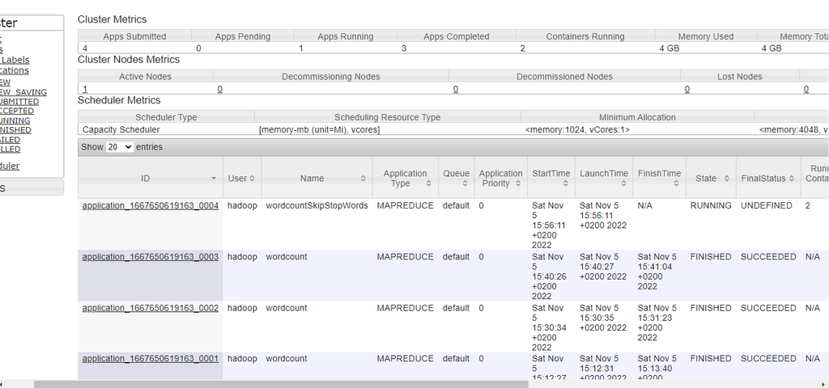

```python
# Put screenshot
Image(filename="/home/bitnami/Big_Data_Labs/lab1/Images/hadoop2.png")
```

```python
# Display the output

!hdfs dfs -cat hadooplab1/output5/part-r-00000
```

```
!	3
!"	1
(	1
),	1
,	13
, "	3
,"	1
-	4
.	3
?"	1
across	2
actually	1
after	2
alice	5
and	8
another	1
as	2
at	1
bank	1
be	2
before	1
beginning	1
book	2
burning	1
but	2
by	2
chain	1
close	1
considering	1
conversations	2
could	1
curiosity	1
daisies	1
daisy	1
day	1
dear	2
did	1
do	1
down	2
either	1
```

[output cut: 76 more lines]

```
very	4
waistcoat	2
was	5
watch	2
way	1
well	1
went	1
what	1
when	2
whether	1
white	1
with	3
without	1
worth	1
would	1
```

```python
!hdfs dfs -cat hadooplab1/output4/part-r-00000
#before stop words
```

```
	212
!	3
!"	1
(	1
),	1
,	13
, "	3
,"	1
-	4
.	3
?"	1
A	8
ACROSS	2
ACTUALLY	1
AFTER	2
ALICE	5
AND	8
ANOTHER	1
AS	2
AT	1
BANK	1
BE	2
BEFORE	1
BEGINNING	1
BOOK	2
BURNING	1
BUT	2
BY	2
CHAIN	1
CLOSE	1
CONSIDERING	1
CONVERSATIONS	2
COULD	1
CURIOSITY	1
DAISIES	1
DAISY	1
DAY	1
DEAR	2
DID	1
DO	1
```

[output cut: 84 more lines]

```
VERY	4
WAISTCOAT	2
WAS	5
WATCH	2
WAY	1
WELL	1
WENT	1
WHAT	1
WHEN	2
WHETHER	1
WHITE	1
WITH	3
WITHOUT	1
WORTH	1
WOULD	1
```

## Task 3:

- Create a function to read the Alice in wonderland text file and perform word count on it.
- Compute the time to run the function.
- Try it on a larger file and compute the time.

```python
import time
t1= time.time()
print("Start time = " ,t1)
input_file = open("AliceInWonderLandPart1.txt", "rt")
content = input_file.read()

def word_count(str):
    counts = dict()
    words = str.split()

    for word in words:
        if word in counts:
            counts[word] += 1
        else:
            counts[word] = 1

    return counts

print( word_count(content))
input_file.close()
t12= time.time()
print("End time = " ,t12)
print("Rtime =", t12 - t1)
```

```
Start time =  1667679058.389856
{'seen': 1, 'when': 2, 'whether': 1, 'on': 1, 'conversations': 1, 'could,': 1, '"and': 1, 'see': 1, 'that,': 1, 'book,"': 1, 'conversations?"': 1, 'getting': 1, 'moment,': 1, 'down': 2, 'went': 1, 'sleepy': 1, 'of': 8, 'way': 1, 'her.': 1, 'or': 4, 'But': 1, 'what': 1, 'curiosity,': 1, 'close': 1, '…
End time =  1667679058.4016376
Rtime = 0.011781454086303711
```

[figure not shown]

```python
Image(filename="/home/bitnami/Big_Data_Labs/lab1/Images/python_1.png")
```

[figure not shown]

```python
Image(filename="/home/bitnami/Big_Data_Labs/lab1/Images/python_2.png")
```

## Describe here the distributed cache technique in two lines maximum

**Answer**

```
A distributed cache is a cache which has its data spread across several nodes in a cluster. Also across several clusters across several data centres located around the globe.

Three key benefits of distributed caching: Scalability, High Availability,Fault-tolerance.
```

## How much time have you spent on this assignment?

##### This question won't affect your grade, it is used to improve the course assignments in the future. So, please try to be accurate as possible.

**Answer**

</font> 4 hours

## What is your feedback on the assignment (Give a rating from 1 to 5)?

##### This question won't affect your grade, it is used to improve the course assignments in the future.

**Answer**

</font> 5